# hw02

## Корреляция

Колонка COUNTYFP содержит числовой код округа внутри штата. Нас интересуют Butte County (округ 7 в Калифорнии), Santa Clara (округ 85 в Калифорнии) и York County (округ 133 в Пенсильвании).

```r
acc <- c()
for (tract in 1:nrow(data2)) {
  if (data2$STATEFP[tract] == 6) {
    if (data2$COUNTYFP[tract] == 1) {
      acc <- c(acc, tract)
    }
  }
}
accmv <- c()
for (tract in acc) {
  accmv <- c(accmv, data2[tract,10])
}
median(accmv)
```

```
## [1] 474050
```

```r
#В переменную acc записываются строки  домовладения округа 1 штата Калифорния. В accmv записываются медианы стоимости домов, и выводится медиана по этим стоимостям.
```

Напишите другим способом в одну строку, то же самое, что делает нижеуказанный код. Способов получить тот же ответ множество, достаточно одного.

```r
median(data2$Median_house_value[data2$STATEFP == 6 & data2$COUNTYFP == 1])
```

```
## [1] 474050
```

```r
mean(data2$Total_units[data2$STATEFP == 6 & data2$COUNTYFP == 7])
```

```
## [1] 1874.294
```

```r
mean(data2$Total_units[data2$STATEFP == 6 & data2$COUNTYFP == 85])
```

```
## [1] 1697.831
```

```r
mean(data2$Total_units[data2$STATEFP == 42 & data2$COUNTYFP == 133])
```

```
## [1] 1975.233
```

Функция cor рассчитывает коэффициент корреляции между двумя переменными. Рассчитайте корреляцию между медианы стоимости домовладений (Median_house_value) и процентом построенных домов (Built_2005_or_later): для всего набора данных

```r
cor(data2$Median_house_value, data2$Built_2005_or_later)
```

```
## [1] -0.01893186
```

для Калифорнии

```r
cor(data2$Median_house_value [data2$STATEFP == 6], data2$Built_2005_or_later [data2$STATEFP == 6])
```

```
## [1] -0.1153604
```

для Пенсильвании

```r
cor(data2$Median_house_value [data2$STATEFP == 42], data2$Built_2005_or_later [data2$STATEFP == 42])
```

```
## [1] 0.2681654
```

для округа Butte County

```r
cor(data2$Median_house_value [data2$STATEFP == 6 & data2$COUNTYFP == 7], data2$Built_2005_or_later [data2$STATEFP == 6 & data2$COUNTYFP == 7])
```

```
## [1] 0.04203267
```

для округа Santa Clara

```r
cor(data2$Median_house_value [data2$STATEFP == 6 & data2$COUNTYFP == 85], data2$Built_2005_or_later [data2$STATEFP == 6 & data2$COUNTYFP == 85])
```

```
## [1] -0.1726203
```

для York County

```r
cor(data2$Median_house_value [data2$STATEFP == 42 & data2$COUNTYFP == 133], data2$Built_2005_or_later [data2$STATEFP == 42 & data2$COUNTYFP == 133])
```

```
## [1] 0.3860773
```

Постройте три диаграммы медианы стоимости домовладений (Median_house_value) относительно медианы дохода (Median_household_income) для трёх округов. Допустимо указать все три на одном графике.

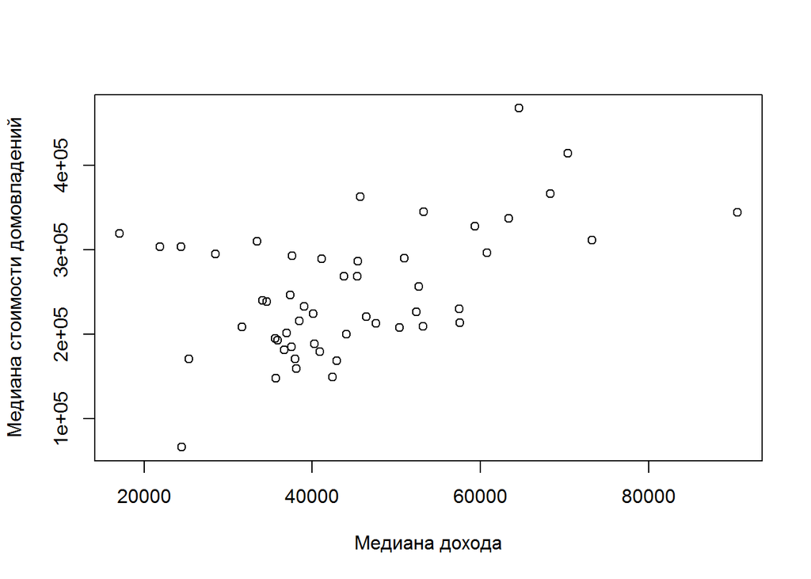

```r
plot(data2$Median_household_income [data2$STATEFP == 6 & data2$COUNTYFP == 7], data2$Median_house_value [data2$STATEFP == 6 & data2$COUNTYFP == 7], xlab="Медиана дохода", ylab = "Медиана стоимости домовладений")
```

для Butte County

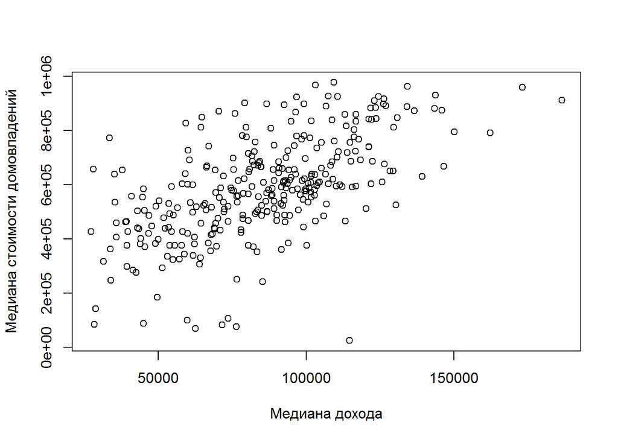

```r
plot(data2$Median_household_income [data2$STATEFP == 6 & data2$COUNTYFP == 85], data2$Median_house_value [data2$STATEFP == 6 & data2$COUNTYFP == 85], xlab="Медиана дохода", ylab = "Медиана стоимости домовладений")
```

для Santa Clara

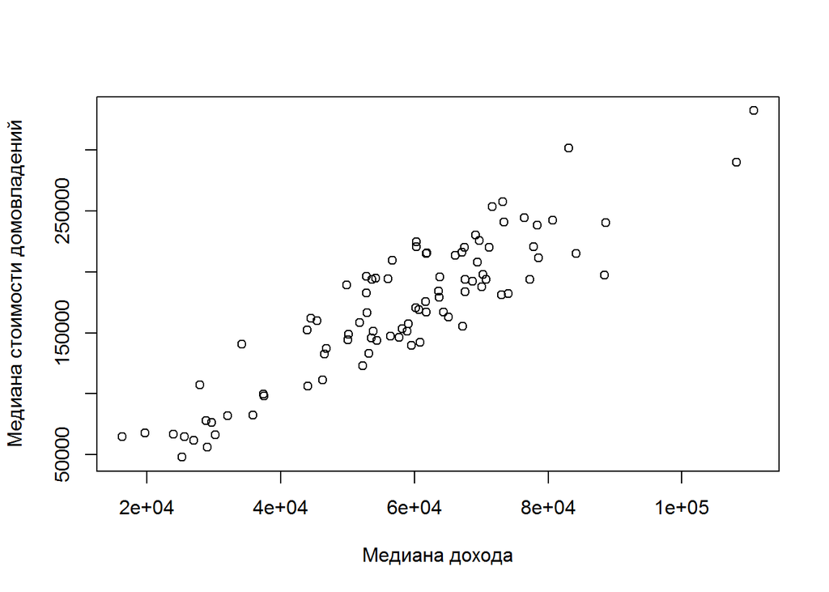

```r
plot(data2$Median_household_income [data2$STATEFP == 42 & data2$COUNTYFP == 133], data2$Median_house_value [data2$STATEFP == 42 & data2$COUNTYFP == 133], xlab="Медиана дохода", ylab = "Медиана стоимости домовладений")
```

для York County